# ETC3250/5250 IML Asignment 3 Solution

Thuy Tien Pham (30806933)

2023-10-06

```r
# Load the packages that you will use to complete this assigment.
library(dplyr)
library(tidyverse)
library(rsample)
library(yardstick)
library(stats)
library(ranger)
library(ggdendro)
library(gridExtra)
library(kknn)
library(ipred)
library(rpart)
library(gbm)
library(xgboost)
```

```r
data <- read_csv("data30806933.csv")
```

## Preliminary analysis

### Question 1

The letter in my data is W.

### Question 2

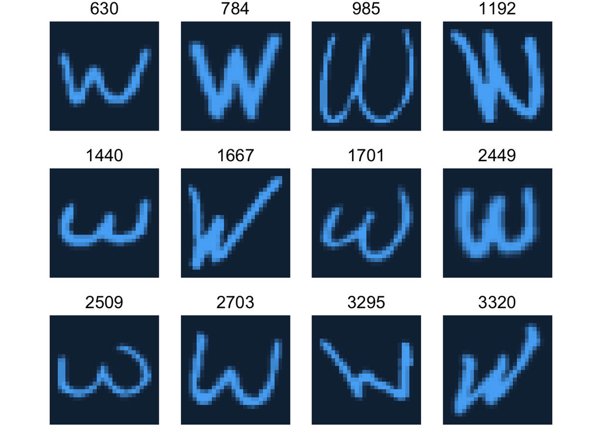

```r
set.seed(17072001)
imagedata_to_plotdata <- function(data = data,
                                  w = 28,
                                  h = 28,
                                  which = sample(1:3418, 12)) {
  data %>%
    mutate(id = 1:n()) %>%
    filter(id %in% which) %>%
    pivot_longer(starts_with("V")) %>%
    mutate(col = rep(rep(1:w, each = h), n_distinct(id)),
           row = rep(rep(1:h, times = w), n_distinct(id)))
}

gletters <- imagedata_to_plotdata(data) %>%
    ggplot(aes(col, row)) +
    geom_tile(aes(fill = value)) +
    facet_wrap(~id, nrow = 3) +
    scale_y_reverse() +
    theme_void(base_size = 18) +
    guides(fill = "none") +
    coord_equal()

gletters
```

### Question 3

```r
data_pca <- prcomp(data)
```

```r
cumsum(data_pca$sdev^2 / sum(data_pca$sdev^2)) %>% head()
```

```
## [1] 0.0994894 0.1821534 0.2454012 0.3037705 0.3571161 0.3920728
```

The total variation that the first 5 principal components explain in the data is 0.3571161.

### Question 4

[figure not shown]

```r
set.seed(1707)
Xnew <- data_pca$x[, 1] %*% t(data_pca$rotation[, 1])

sample_ids <- sample(1:3418, 1)

Pdata <- as.data.frame(Xnew) %>%
  imagedata_to_plotdata(which = sample_ids)
PC1_loading <- Pdata %>%
  ggplot(aes(col, row)) +
    geom_tile(aes(fill = value)) +
    scale_y_reverse() +
    theme_void(base_size = 18) +
    guides(fill = "none") +
    coord_equal()
PC1_loading
```

[figure not shown]

```r
set.seed(1707)
Xnew2 <- data_pca$x[, 2] %*% t(data_pca$rotation[, 2])

sample_ids <- sample(1:3418, 1)

Pdata <- as.data.frame(Xnew2) %>%
  imagedata_to_plotdata(which = sample_ids)
PC2_loading <- Pdata %>%
  ggplot(aes(col, row)) +
    geom_tile(aes(fill = value)) +
    scale_y_reverse() +
    theme_void(base_size = 18) +
    guides(fill = "none") +
    coord_equal()
PC2_loading
```

### Question 5

```r
haverage <- hclust(dist(data_pca$x), method = "average")
haverage
```

```
##
## Call:
## hclust(d = dist(data_pca$x), method = "average")
##
## Cluster method   : average
## Distance         : euclidean
## Number of objects: 3418
```

### Question 6

```r
c_average <- cutree(haverage, k =4)
table(c_average)
```

```
## c_average
##    1    2    3    4
## 3406    6    5    1
```

### Question 7

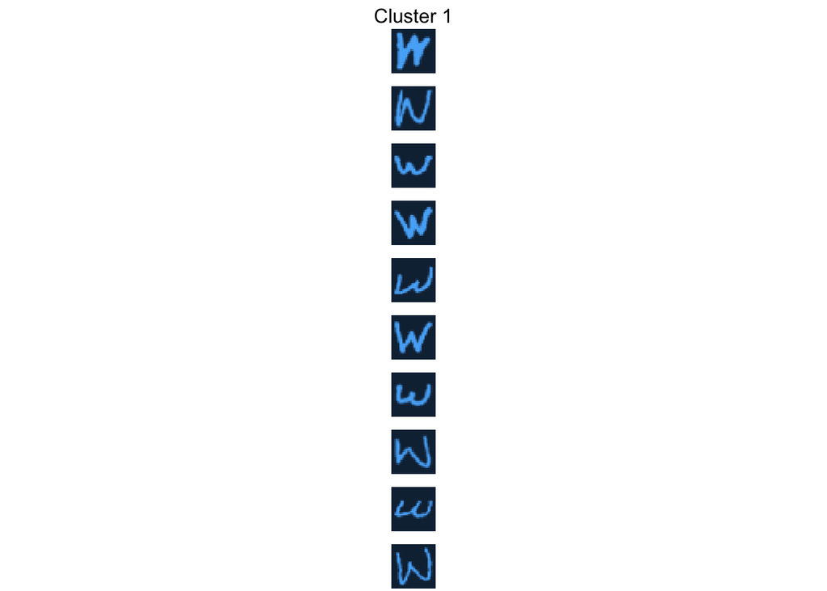

```r
set.seed(1707)
data_labels <- data %>%
  mutate(caverage = c_average) %>%
  imagedata_to_plotdata(which = sample(1:3418, 3418))

cluster1 <- data_labels %>%
  filter(caverage == 1) %>%
  filter(id %in% 1:10)

cluster_plot1 <- cluster1 %>%
  ggplot(aes(col, row)) +
    geom_tile(aes(fill = value)) +
    facet_wrap(~id, nrow = 10) +
    scale_y_reverse() +
    theme_void(base_size = 10) +
    guides(fill = "none") +
    coord_equal() +
    ggtitle("Cluster 1") +
    theme(strip.background = element_blank(), strip.text.x = element_blank(),  plot.title = element_text(hjust = 0.5))
cluster_plot1
```

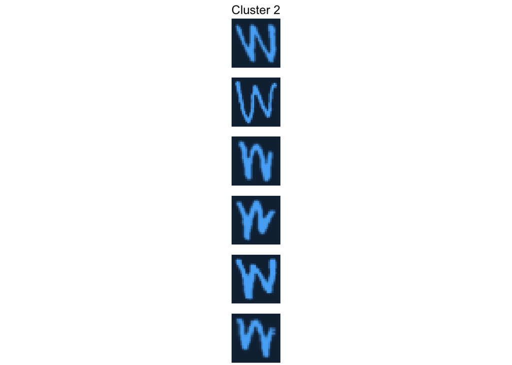

```r
set.seed(1707)
cluster2 <- data_labels %>%
  filter(caverage == 2)

cluster_plot2 <- cluster2 %>%
  ggplot(aes(col, row)) +
    geom_tile(aes(fill = value)) +
    facet_wrap(~id, nrow = 6) +
    scale_y_reverse() +
    theme_void(base_size = 10) +
    guides(fill = "none") +
    coord_equal() +
    ggtitle("Cluster 2") +
    theme(strip.background = element_blank(), strip.text.x = element_blank(),  plot.title = element_text(hjust = 0.5))
cluster_plot2
```

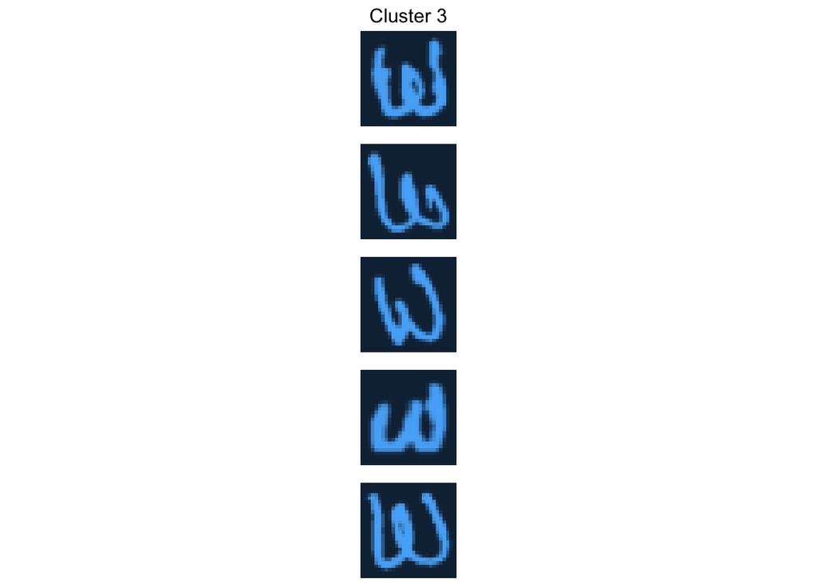

```r
set.seed(1707)
cluster3 <- data_labels %>%
  filter(caverage == 3)

cluster_plot3 <- cluster3 %>%
  ggplot(aes(col, row)) +
    geom_tile(aes(fill = value)) +
    facet_wrap(~id, nrow = 5) +
    scale_y_reverse() +
    theme_void(base_size = 10) +
    guides(fill = "none") +
    coord_equal() +
    ggtitle("Cluster 3") +
    theme(strip.background = element_blank(), strip.text.x = element_blank(),  plot.title = element_text(hjust = 0.5))

cluster_plot3
```

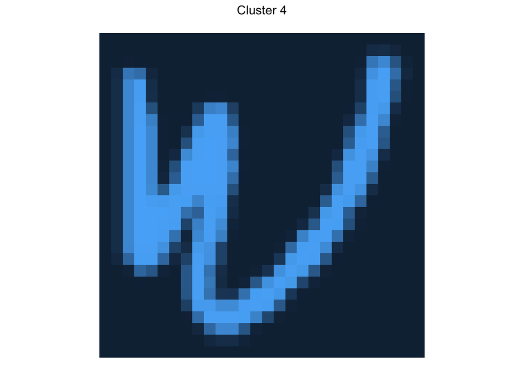

```r
set.seed(1707)
cluster4 <- data_labels %>%
  filter(caverage == 4)

cluster_plot4 <- cluster4 %>%
  ggplot(aes(col, row)) +
    geom_tile(aes(fill = value)) +
    facet_wrap(~id, nrow = 1) +
    scale_y_reverse() +
    theme_void(base_size = 10) +
    guides(fill = "none") +
    coord_equal() +
    ggtitle("Cluster 4") +
    theme(strip.background = element_blank(), strip.text.x = element_blank(), plot.title = element_text(hjust = 0.5))
cluster_plot4
```

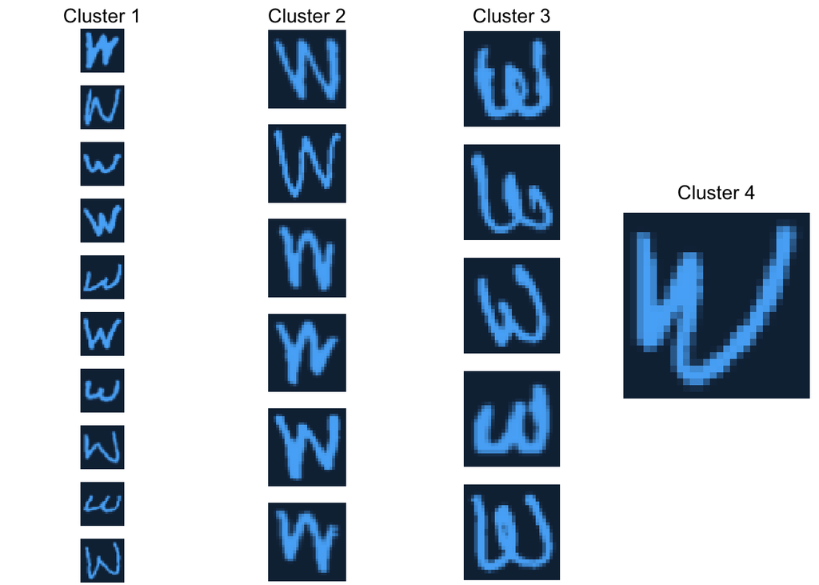

```r
gridExtra::grid.arrange(cluster_plot1, cluster_plot2, cluster_plot3, cluster_plot4, ncol = 4)
```

Each cluster group has a similar way of writing letter W. For example, all observations in cluster 2 has a straight letter W, and the way W is written is sharp. Cluster 3 has another way for writing letter W that it looks softer than cluster 2. But cluster 1 appears to be different since not all observations have a similar look, and that could not tell us much about the majority of cluster 1. Cluster 4 only has only one observation and it also doesnt tell us much about the way of writing letter W.

### Report

# Read the newrecord data

```r
newrecords <- read_csv("newrecords30806933.csv") #read the newrecord data
```

# Doing PCA on the newrecord data

```r
newrecord_pca <- prcomp(newrecords) # Doing PCA on the new record data
```

```r
hward_new <- hclust(dist(newrecord_pca$x), method = "ward.D2") # using Ward's method to make a tree
cward_new <- cutree(hward_new, k = 5) # cut the previous tree into 5 clusters
```

```r
newrecord_pca1 <- data.frame(newrecord_pca$x) %>%  # add the column cluster into the data frame
  mutate(cluster = as.factor(cward_new))
```

## Draw a dendogram to build a tree of the main data

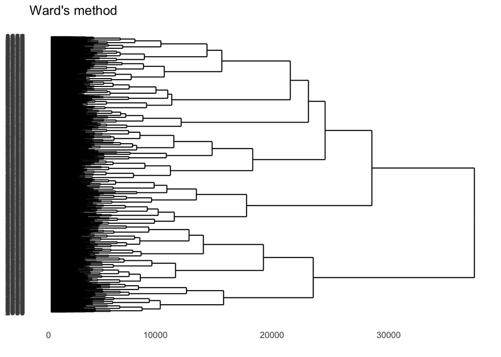

```r
# agglomerative hierarchical clustering with Ward's method to split the main data
hward <- hclust(dist(data_pca$x), method = "ward.D2")
ggdendrogram(hward, rotate = TRUE) + labs(title = "Ward's method")
```

I plot a dendogram to visualize the tree so I could decide how many clusters that I want. It is quite sensible to cut the tree into 7 when we look at the dendogram since some of these 7 trees have quite similar number of smaller tree. If we have more trees, it wont be sensible anymore when looking at the dendogram.

# Cut tree to divide clusters of the main data

```r
cward <- cutree(hward, k = 7)
table(cward)
```

```
## cward
##   1   2   3   4   5   6   7
## 359 555 627 350 568 726 233
```

# Plots the clusters of the main data

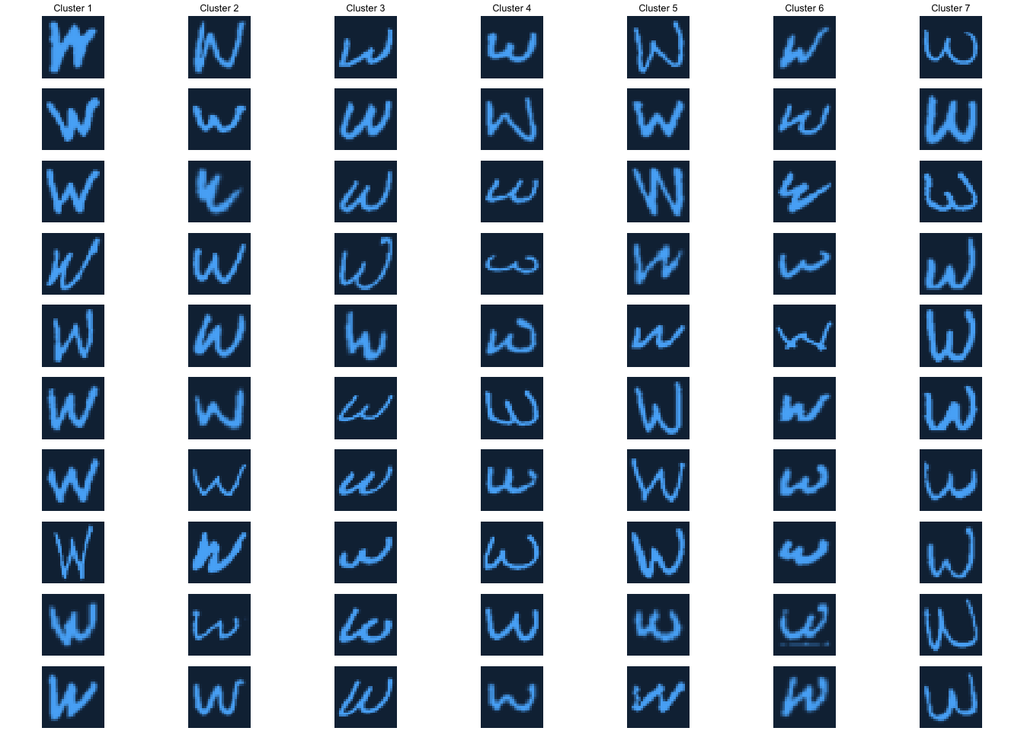

```r
# show the sample images of 10 clusters from the main data
set.seed(1707)
data_labels <- data %>%
  mutate(c_ward= cward) %>%
  imagedata_to_plotdata(which = sample(1:3418, 3418))

plots <- list()

for (i in 1:7) {
  cls <- data_labels %>%
  filter(c_ward == i)

  ids <- head(unique(cls$id), 10)

  cls <- cls %>%
    filter(id %in% ids)

cls_plot <- cls %>%
  ggplot(aes(col, row)) +
    geom_tile(aes(fill = value)) +
    facet_wrap(~id, nrow = 10) +
    scale_y_reverse() +
    theme_void(base_size = 4) +
    guides(fill = "none") +
    coord_equal() +
    ggtitle(paste("Cluster", i)) +
    theme(strip.background = element_blank(), strip.text.x = element_blank(),  plot.title = element_text(hjust = 0.5))
plots[[i]] <- cls_plot
}
grid.arrange(plots[[1]],plots[[2]],plots[[3]],plots[[4]],plots[[5]],plots[[6]],plots[[7]],
            ncol = 7)
```

If we look at the plots, we could see that most of observations that look similar to each other belong to one cluster. Cluster 1: all the observations look straight and sharp, and look like these letters have been written carefully. Cluster 2: all letters in this cluster look a bit sharp, and they fall a little bit to the right. Cluster 3: these obsevations tend to fall to the right, and they look smaller than other groups. Cluster 4: Letter W in this group have been written like 2 letter U, they look round and soft. Cluster 5: These observations are quite large compared to other groups, and it look sharp but not really straight. Cluster 6: These letters are written carelessly, they fall to the right just a bit. Cluster 7: all letters in this group look soft and straight, and written carefully.

# Convert data_pca into a data frame

```r
# convert data_pca$x into a data frame
data_pca1 <- data.frame(data_pca$x)
```

# Add column ‘cluster’ into the data frame

```r
data_pca1 <- data_pca1 %>% # add the cluster column into data frame
  mutate(cluster = as.factor(cward))
```

# Create training set and testing set to make and evaluate model

```r
set.seed(1707)
# create the testing and training set from the main data
data_split <- initial_split(data_pca1)
train_data <- training(data_split)
test_data <- testing(data_split)
```

## Random forest model

```r
# Random forest model
set.seed(1707)
rf_model <- ranger(cluster ~ .,
                   data = train_data,
                   mtry = floor((ncol(train_data) - 1)/3),
                   importance = "impurity",
                  replace = FALSE,
                   classification = TRUE)
rf_pred <- predict(rf_model, test_data)
```

```r
accuracy_rf <- accuracy_vec(truth = test_data$cluster, estimate = rf_pred$predictions) # check the accuracy of the model
accuracy_rf
```

```
## [1] 0.7450292
```

```r
# Check the balance accuracy
bal_accuracy_rf <- bal_accuracy_vec(truth = test_data$cluster, estimate = rf_pred$predictions)
bal_accuracy_rf
```

```
## [1] 0.8497026
```

The accuracy of this model is 74.5% and balance accuracy is approximately 85%.

## k-nearest neighbor model

```r
# k-nearest neighbor model
set.seed(1707)
knn_pred <- kknn(cluster ~ .,
                 train = train_data,
                 test = test_data,
                  k = 30,
                 # parameter of Minkowski distance
                 # 2 = Euclidean distance
                 # 1 = Manhattan distance
                 distance = 2)
```

```r
accuracy_knn <- accuracy_vec(truth = test_data$cluster, estimate = as.factor(knn_pred$fitted.values))
accuracy_knn
```

```
## [1] 0.4736842
```

```r
bal_accuracy_knn <- bal_accuracy_vec(truth = test_data$cluster, estimate = as.factor(knn_pred$fitted.values))
bal_accuracy_knn
```

```
## [1] 0.6450336
```

The accuracy of this model is 47% and balance accuracy is approximately 64.5%. This is not a good model since the accuracy rate is really low (less than 50%), therefore it is not realiable.

## XGB model

```r
# XGB model
set.seed(2000)
xgb_model <- xgboost(data = model.matrix(~ . - cluster, data = train_data)[, -1],
                     label = train_data$cluster,
                     max.depth = 2,
                     eta = 0.3,
                     nrounds = 50,
                     num_class = 8,
                     objective = "multi:softprob",
                     verbose = 0)
xgb_pred <- predict(xgb_model, model.matrix(~. - cluster, data = test_data)[, -1])
xgb_pred <- matrix(xgb_pred, ncol = 8, byrow = TRUE)
xgb_pred <- max.col(xgb_pred) - 1
```

```r
bal_accuracy_xgb <- bal_accuracy_vec(truth = test_data$cluster, estimate = as.factor(xgb_pred))
bal_accuracy_xgb
```

```
## [1] 0.8497035
```

```r
accuracy_xgb <- accuracy_vec(truth = test_data$cluster, estimate = as.factor(xgb_pred))
accuracy_xgb
```

```
## [1] 0.7438596
```

The accuracy of this model is 74% and balance accuracy is approximately 85%.

# Evaluate models

As we can see from the accuracy and balance accuracy rate of 3 models, it appears that kNN performs worst. It could not predict well with the data. So we could not use that one for predicting newrecord data.

Random forest model and XGB model have similar performance since the accuracy rate and balance accuracy rate of them are quite similar (about 85% for the balance accuracy). Therefore, we could use these two models to predict the new record data.

Moreover, 85% for a model is a quite sensible rate when it comes to prediction. Not all model could predict 100% correctly, and it also depends on the data and how the clusters are divided.